# Marketing Data Manual

Group Assignment - Open Source Programming 2021

MEDINAMARTINEZ Juanjose, KELLY Elina, VELLINGIRI KOWSALYA Swasthik

### **Introduction**

Most of the organisations today are trying to update themselves in the best possible way to understand their customers in depth and to plan various strategies to increase their revenue. It is obvious to improve the customer experience and the business by directly looking at the customer behavior than planning strategies based on assumption. Even just by understanding the raw database without any analyst can give interesting information to the business. Hence companies now spend a lot of money in analyzing and predicting their customers based on the data they have collected. Companies of all industries including the gambling industry are getting data driven to expand their business and boost profits.

This report provides insights and analyses on customers for an online gambling website with the objective of identifying trends and common behavior among customers through interesting marketing metrics. This report will help the company and the marketing team to plan their strategies accordingly and will also help in making business decisions. The raw data collected regarding the company was transformed and analyzed by using graphs. All the information and the insights gained are further discussed in the report.

The most important part in creating insights is the data. The better and the more there are data, the better the information gathered out of it. The raw information provided on the players consists of three datasets. The first dataset consists of the demographic information such as the country they are from, language, gender and the date of registration and their first play dates on different types of games. The second dataset consists of the betting information of the players on different products including the date. It also consists of the winnings, stakes and the number of bets for each session. The data set consists of the transaction information of the pokers for each poker session. It includes the type of transaction i.e. buy or sell.

### **Datamart**

In order to develop insights from the raw database, a datamart was created based on the three raw datasets mentioned above. These datasets were aggregated, grouped and merged to form a single data table. The final table consists of information with each row corresponding to each player. Along with the basic information in the raw datasets, several new variables have been created to add more value and to gather more insights. The final table contains the list of customers who registered during the period of February 1, 2005 until February 27, 2005. The datamart has 47 variables which includes the demographic information, poker chip transaction and all the betting information with respect to the players. The datamart is then used to create graphs and to extract valuable insights.

### **Customer overview**

#### Customers Based on Country and Languages

As of October 2nd, 2005 the online gambling website has attracted users from 81 countries around the world since February 1st, 2005. The bar chart below displays the ranking of the top 10 countries with the number of users as values represented on the horizontal axis.

It is evident by looking at the graphs, that the majority of the customers are located in Germany with 24,169 accounts, followed by Turkey, Poland, Spain, Greece and France with approximately 2,000 accounts each. This high number of users in those countries could be an explanation for the graph below with the distribution of users on the various applications.

The languages ranking is similar to the countries ranking. However there are some differences, for instance Greek is ranked 3rd in languages with 2,437 speakers and only 2,392 players in the country, this could potentially indicate that some Greek players are residing and playing in countries other than Greece.

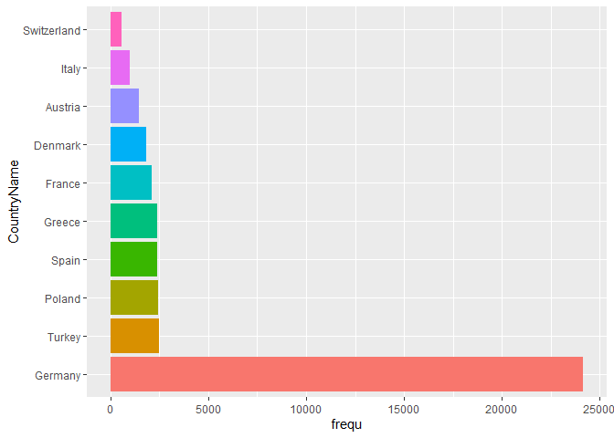

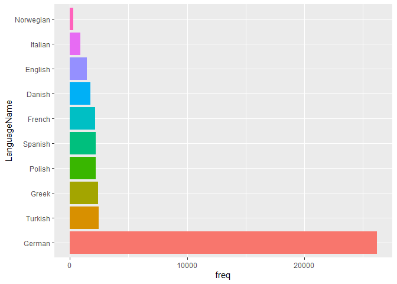

#### Customers Based on Gender

Gender is another important customer based variable. As the per the data, it is found that more than 80% of the customers registered between 1st and 27th of February, 2005 were males. This makes the males as the priority customers. However, as we can see a small group of women in our data, the company can take some steps to promote more female customers by offering some discounts. This step would not only increase the number of customers but also the revenue in the long run.

Note: 1 = Male and 0 = Female

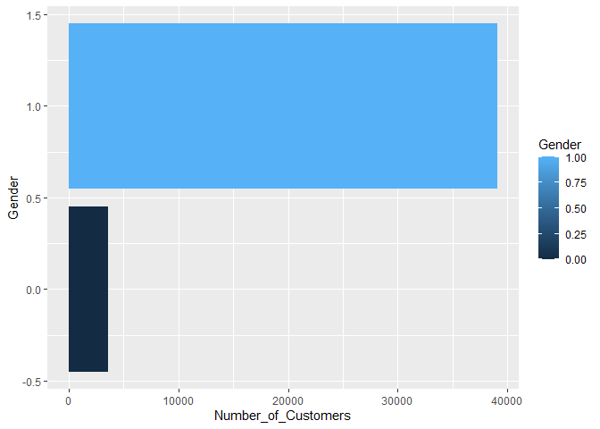

#### Customers Based on Recency and Frequency

Finding the recency and frequency of the customers will enable the company on how the customers interact. The below recency plot shows that most of the customers recently interacted that is they had played recently. There is also quite bunch of customers who did not play since 200 days.

The frequency chart shows that most of the customers played or visited less than 50 times while there are more than 5000 customers who visited more than 50 times.There are also some customers who visited around 200 times.

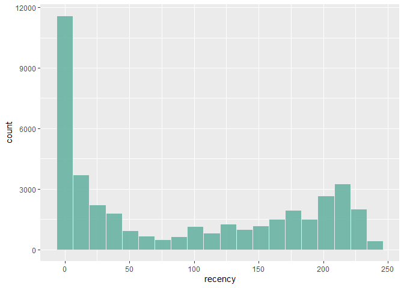

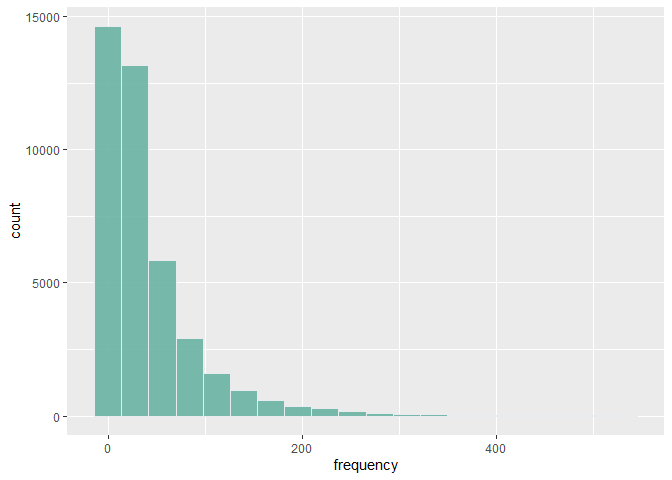

### **Applications and Products**

#### Popularity of Applications

The online gambling website owns 22 applications and subdomains in total, this could be due to specific country rules and regulations, for instance the legal age to bet, or simply customers who might trust more a certain domain like .DE than others.  
The graph below represents the number of users by application.

The 2 bars that visibly overshadow the other existing applications correspond to Betandwin.de and Betandwin.com with 22,042 and 14,502 users respectively.  
The other applications that succeed the 2 most popular ones with a big drop in number of users are Beteurope.com (2,360 users), Betoto.com (2,144 users) and Betandwin Poker (483 users).

The previous graph showing the top 10 countries with the most users coincides with the Popularity of Applications graph. Those countries provide access to a high number of applications in contrast to the majority of countries where users only have access to 2 or 3 applications. For instance German users have the possibility to use 11 different applications, Turkey 10, Poland 9, Spain 9 and Greece 11 in total.

What can be relevant to note about the top 5 applications that are used the most is that the first one Betandwin.de is present only in 2 countries, in contrast to the second one Betandwin.com is in 79 countries and the third, fourth and fifth, respectively Beteurope.com, Betoto.com and Betandwin Poker are in approximately 20 countries.

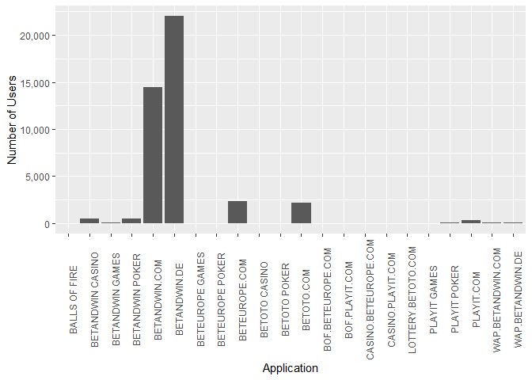

#### Products Based on Popularity

This graph displays the various betting products each players have betted on. Casino Chartwell is the most trendy one, followed by Sports book fixed-odd and Sports book live-action.

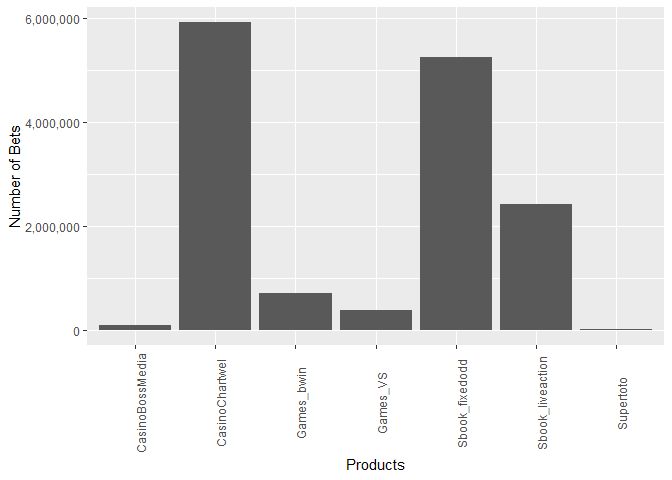

### **Game Types**

#### Players Based on Game type

The online gambling website offers a selection of 3 game types: casino, games and poker, the pie chart showcases the popularity of each of these games. The majority of the customers are casino players (5,888 people), followed by games players (3,273 people) and finally poker players with (2,142 people).  
Interestingly the most popular game is not necessarily the one that attracts the most female players, who tend to play more games (10%) than casino (9%) or poker (7%) with a slight difference in percentage.

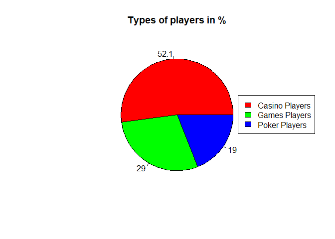

#### Total Stakes and Total winnings distrubution

The following graphs demonstrate the amount bet by the customers, called total stakes. It is based on the number of customers, to be read by interval. This means that there are approximately 3,750 customers who bet $ 625, the number of customers winning the same amount are fewer.

The gap between the amount the total stakes, and the total winning corresponds to the Gross gaming revenue (GGR) for the company. In other words, it is the money the company retains at the end, so their profit. The profit made by the company will be discussed below.

Note: The big bunch of customers on the right side of the plot are the number of customers whose values are more than the customers of the 95% percentile. This indication is to show the number of customers who either over played or the outliers in the data.

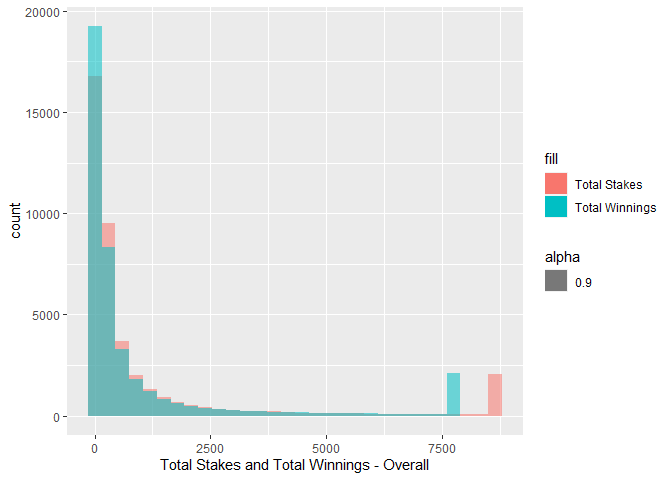

### **Metrics Based on Days of the Week**

#### Total Stakes VS Average Stakes - Based on Days of the week

Some specific days of the week are more or less important than others, this is a parameter that needs to be taken into account as it says a lot about the playing patterns of the customers.

Customers tend to make more bets during the weekdays, however on weekends, so in other words in a total of 2 days (4,773,260 bets), the amount of bets is as high as half of the amount of bets made during 5 days during the week (10,025,350 bets).

The graphs represent the total stakes or the average stakes based on the day of the week. They indicate that the total stakes are the lowest for Monday (a bit over $ 13,000,000), in comparison to the highest days of the week that correspond to Saturday ($ 19.000.000) and Sunday ($ 18,000,000). However, the average stakes per day of the week are the highest on Friday ($ 80) and Monday ($ 75). This could mean that on those days, less people bet than on other days of the week or the weekend, however the amount bet by the few customers is high, resulting in a rather high average for those days.

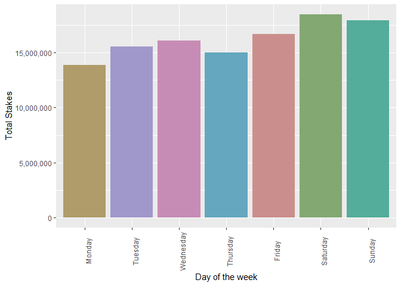

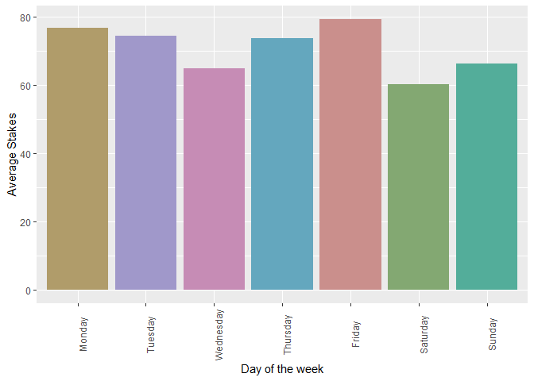

#### Total Bets VS Average Bets - Based on Days of the week

The graphs below displaying the total bets or the average bets based on the day of the week are coherent with the previous findings from the graphs above. The day with the lowest bet is matching that of the total stakes. The total of 1,800,000 bets made on a Monday amount to $ 13,000,000. This can be justified by the assumption that on a monday where people begin their new week after getting back from 2 days of freedom, they have a lot on their plate or tasks to accomplish, thus, gambling might not be a priority on this particular day of the week.

During the weekdays, the day with the highest number of bets is on Friday. This could be related to what is called the “Gambler’s Fallacy”, where gamblers believe a certain thing, based on superstitions they may have instead of just randomness and probabilities or coincidences. It is said that there is a belief shared by gamblers that says that the best timing to gamble is a Friady between 6pm and 10pm. This could explain the peak for Friday on weekdays.

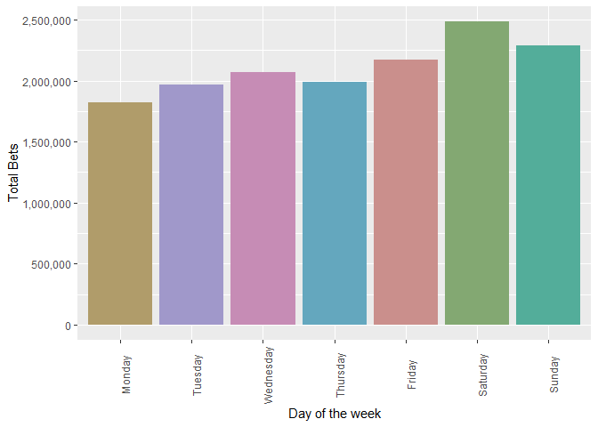

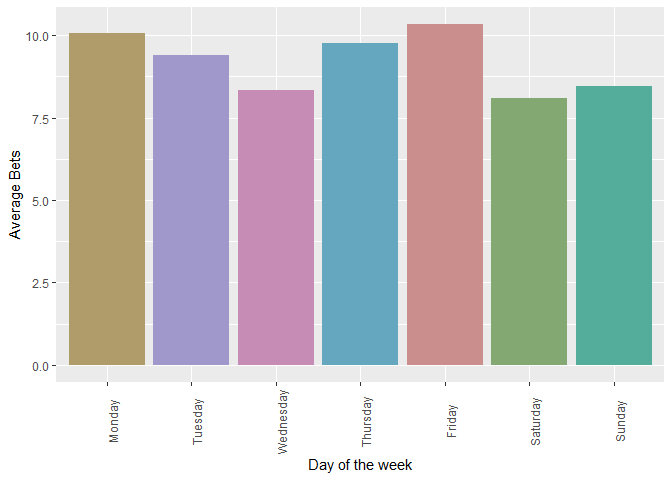

#### Total winnings VS Average winnings - Based on Days of the week

The graphs indicate the total winnings or the average winnings based on the day of the week. What is interesting for the winnings is that the total is highest for Saturday and Sunday equally, and the lowest is on a Monday. However, when looking at the average winnings, the highest average is on Monday, then Friday, Sunday and Tuesday in the order. The bars on the average winnings graph do not fluctuate accordingly to the bars on the total winnings graph. This could be a sign of randomness generated by the online gambling website or, on days where the total winnings are high, the payout rate of games might be lower, meaning if the customers have an equal chance of winning on every day of the week and all the players play on one day, it might be difficult to handle for the company.

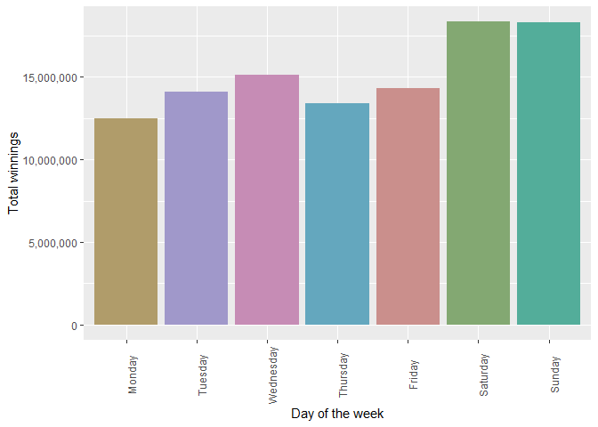

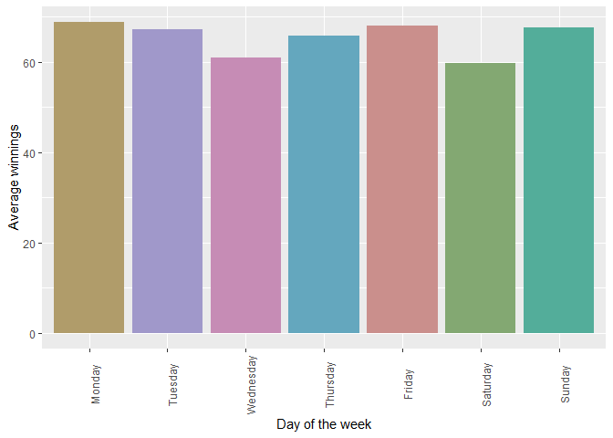

### **Metrics Based on the Game types**

#### Poker: Total Stakes Histogram VS Total winnings Histogram

It has been highlighted above that the total stakes are usually higher than the total winnings for all games combined. Below, we will study the difference between total and average stakes and winnings based on the specific game types. The graph below represents the total stakes amount for a certain number of customers for poker. It could be worthwhile to compare those results to the average stakes and winnings.

Note: The big bunch of customers on the right side of the plot are the number of customers whose values are more than the customers of the 95% percentile. This indication is to show the number of customers who either over played or the outliers in the data.

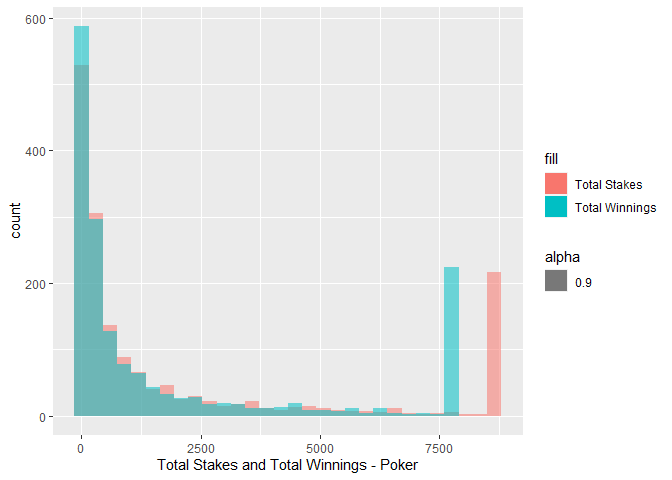

#### Poker: Average Stakes Histogram VS Average winnings Histogram

Note: The big bunch of customers on the right side of the plot are the number of customers whose values are more than the customers of the 95% percentile. This indication is to show the number of customers who either over played or the outliers in the data.

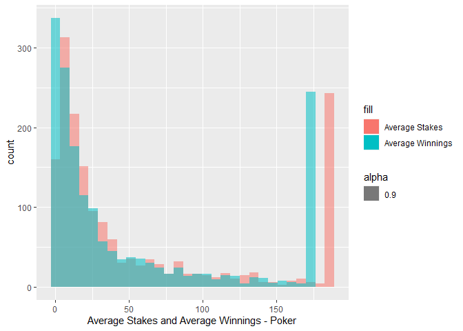

#### Games: Total Stakes Histogram VS Total winnings Histogram

Note: The big bunch of customers on the right side of the plot are the number of customers whose values are more than the customers of the 95% percentile. This indication is to show the number of customers who either over played or the outliers in the data.

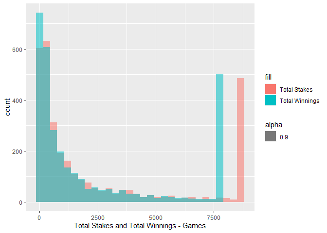

#### Games: Average Stakes Histogram VS Average Winnings Histogram

According to the graph below showing the average stakes and average winnings for games players, customers spend over x1.5 times more than in poker. For instance, for poker, only 310 players bet $ 10 on average versus 630 players who bet $ 10 for the games.

Note: The big bunch of customers on the right side of the plot are the number of customers whose values are more than the customers of the 95% percentile. This indication is to show the number of customers who either over played or the outliers in the data.

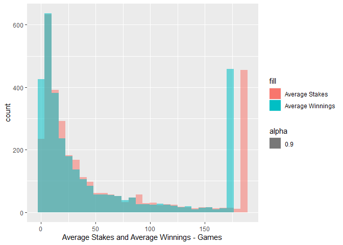

#### Casino: Total Stakes Histogram VS Total winnings Histogram

The total stakes and winnings histograms for casino have a similar pattern to that of poker and games. Naturally the total amounts are higher than the other types of games as it is the most popular one out of the three. However, the difference is noticeable in the average stakes and winnings, as it is demonstrated in the graph below.

Note: The big bunch of customers on the right side of the plot are the number of customers whose values are more than the customers of the 95% percentile. This indication is to show the number of customers who either over played or the outliers in the data.

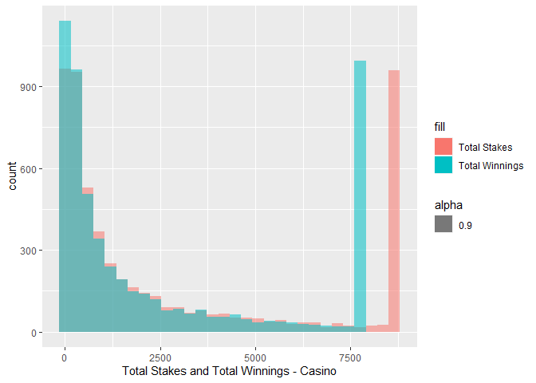

#### Casino: Average Stakes VS Average winnings Histogram

As it is displayed, the difference in gaps between average stakes and winnings are minor and less noticeable than the other games. This means that the player does not lose as much as in other games, in other words their chances of winning are a bit higher than poker or games.

Note: The big bunch of customers on the right side of the plot are the number of customers whose values are more than the customers of the 95% percentile. This indication is to show the number of customers who either over played or the outliers in the data.

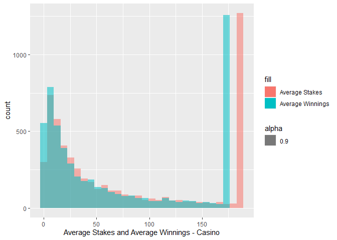

### **In Depth Analysis for Poker**

#### Poker: Amount of Tokens Bought VS Tokens Sold per day

An analysis of the graph below including the average number of chips bought or sold and the number of customers for that specific amount illustrates that the customers buy chips in larger quantities on average and sell a smaller quantities of what they bought. That is why the average chips buy are shifted more to the right side of the graph (higher quantities) compared to the average chips sell that have a peak in quantities between 1 and 2. This also explains the similar figure of the average chips buy to the average vhips sell as the poker players only sell a portion of their average chips buy every time.

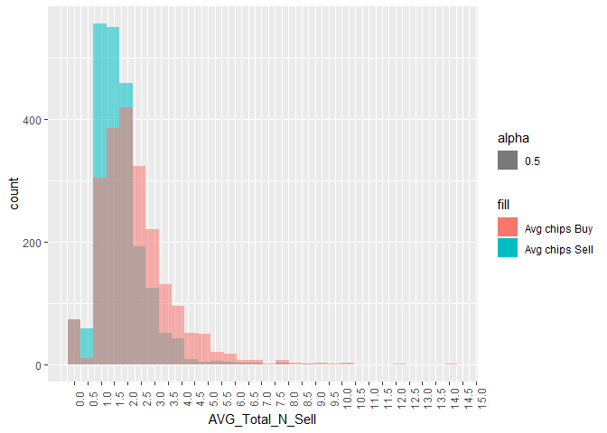

#### Profit for the Company Based on Poker players

It is essential for the company to be aware of the countries in which they make the highest profit.  
In the first part of the report, the graph Customers Based on Country indicated that the top countries were Germany, Turkey, Poland, Spain and Greece. For poker in particular, the countries that bring in the highest profit for the company are Sweden, Denmark, Austria, Germany and Norway. It is surprising to see that the profit of Germany only equals 1/3 of Sweden, considering there are 24,169 players for all types of games and only 190 players. This could be because online poker was banned before 2021 in Germany accoding to the websites SportsKhabri and Fieldfisher.

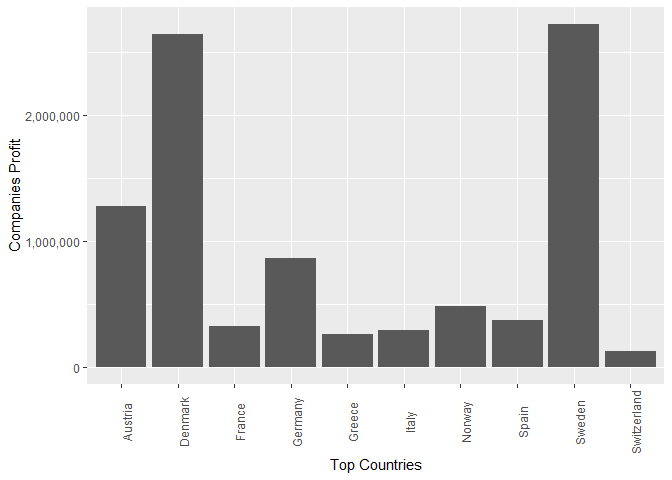

### References

- https://corporatefinanceinstitute.com/resources/knowledge/finance/gross-gaming-revenue-ggr/
- https://nativenewsonline.net/advertise/branded-voices/how-to-choose-the-right-day-of-the-week-to-go-to-the-casino
- https://www.fieldfisher.com/en/insights/germany-allows-online-gambling
- https://sportskhabri.com/top-10-poker-playing-nations-2020/